# Mapping global distribution for any taxonomic level

Here in this article, we show how to use the package’s function `powoMap` for mapping the global distribution for any genus or family of plants either at political country or botanical country levels, following the [World Geographical Scheme for Recording Plant Distributions](https://www.tdwg.org/standards/wgsrpd/). The `powoMap` can use as input data the dataframe-formatted resulting query from `powoSpecies` function or an external spreadsheet. Then, `powoMap` can automatically create one global distribution map for the entire group (e.g., order, family) or multiple maps for each desired taxonomic level within the input data (e.g., genus). The map is colored according to the species richness using either [Viridis](https://CRAN.R-project.org/package=viridis) or RColorBrewer color palettes.

# Setup

Install the latest development version of **expowo** from [GitHub](https://github.com/):

```r
#install.packages("devtools")
devtools::install_github("DBOSlab/expowo")
```

```r
library(expowo)
```

# 1. Mining species distribution from POWO to use as input data in powoMap

To create global distribution maps using `powoMap` function, you can either import a spreadsheet or use the package’s `powoSpecies` function to get distribution information for the species of the target family or genus. It is possible to adjust one of the arguments in `powoSpecies` function to extract data only from a genus or list of genera.

The example below shows how to mine the distribution for an specific genus of Lecythidaceae. By defining a vector within the argument `genus`, here the function will search for all species and associated distribution data for just the genus *Cariniana*. Note that we create an object called `mapspdist`, which is the dataframe-formatted input data to create the map. The output shown here (TABLE 1) is a simplified version, where we have removed some columns so as to focus on the display of just the distribution data.

```r
mapspdist <- powoSpecies(family = "Lecythidaceae",
                         genus = "Cariniana",
                         hybridspp = FALSE,
                         country = NULL,
                         verbose = TRUE,
                         save = FALSE,
                         dir = "results_powoSpecies",
                         filename = "Lecythidaceae_Cariniana")
```

TABLE 1. A general `powoSpecies` search for mining distribution of the Lecythidaceae genus *Cariniana*.

| family | taxon_name | native_to_country | native_to_botanical_countries | kew_id |
| --- | --- | --- | --- | --- |
| Lecythidaceae | Cariniana domestica | Bolivia, Brazil | Bolivia, Brazil North, Brazil West-Central | 592121-1 |
| Lecythidaceae | Cariniana estrellensis | Bolivia, Brazil, Paraguay | Bolivia, Brazil North, Brazil Northeast, Brazil South, Brazil Southeast, Brazil West-Central, Paraguay | 47516-2 |
| Lecythidaceae | Cariniana ianeirensis | Bolivia, Brazil | Bolivia, Brazil Southeast | 47518-2 |
| Lecythidaceae | Cariniana legalis | Brazil | Brazil Northeast, Brazil Southeast | 592126-1 |
| Lecythidaceae | Cariniana micrantha | Bolivia, Brazil | Bolivia, Brazil North, Brazil West-Central | 47522-2 |
| Lecythidaceae | Cariniana parvifolia | Brazil | Brazil Southeast | 302134-2 |
| Lecythidaceae | Cariniana penduliflora | Brazil | Brazil North | 47527-2 |
| Lecythidaceae | Cariniana pyriformis | Colombia, Venezuela | Colombia, Venezuela | 592127-1 |
| Lecythidaceae | Cariniana rubra | Brazil | Brazil North, Brazil Southeast, Brazil West-Central | 592128-1 |

# 2. Creating global-scale map for one genus to show species richness at political country level

To generate a global distribution map for one genus that show species richness at political country level, you can use the previously generated `mapspdist` object as input data of the `powoMap` function and set the `distcol` argument as “native_to_country”. This is the very column of the dataframe-formatted `mapspdist` object that is associated to species distribution at political country.

The example below shows how to create the global distribution map of *Cariniana*’s species richness as colored by the `viridis` palette of the **Viridis** package. If you set up both the arguments `vir_color` and `bre_color` with any of the **Viridis** and **RColorBrewer** color palettes, then two maps colored respectively by these color vectors will be automatically generated. Different file formats and resolutions (e.g. JPG, PDF, PNG, TIFF) are also supported by setting the arguments `format` and `dpi`.

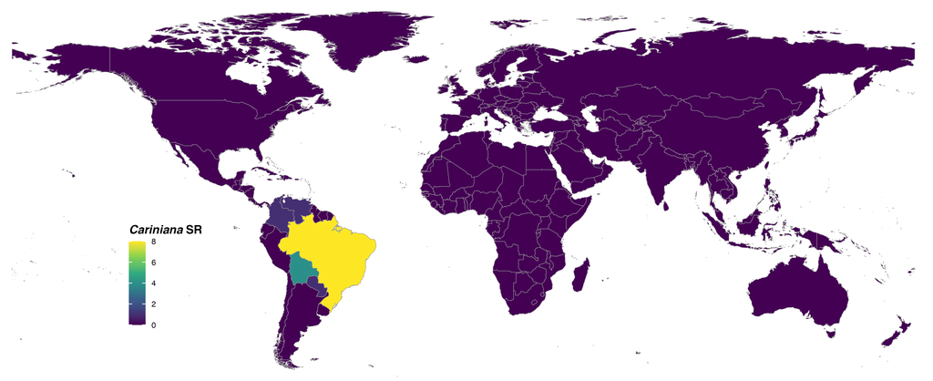

FIGURE 1. Global species richness of the genus *Cariniana* at country level and colored with viridis scale.

```r
powoMap(inputdf = mapspdist,
        botctrs = FALSE,
        distcol = "native_to_country",
        taxclas = "genus",
        verbose = FALSE,
        save = FALSE,
        vir_color = "viridis",
        bre_color = NULL,
        leg_title = "SR",
        dpi = 600,
        dir = "results_powoMap",
        filename = "global_richness_country_map",
        format = "jpg")
```

# 3. Creating global-scale map for one genus to show species richness at botanical country level

To generate a global distribution map for one genus that show species richness at botanical country level, adjust the argument `botctrs` within the `powoMap` function to TRUE. Then, use the previously generated `mapspdist` object as input data in `inputdf` and set the `distcol` argument to the name of the column with distribution according to botanical countries between quotation marks. This is the column of the dataframe-formatted `mapspdist` object or from an external spreadsheet.

The example below shows how to create the global distribution map of *Cariniana*’s species richness according to botanical countries and colored by the `viridis` palette of the **Viridis** package. If you set up both the arguments `vir_color` and `bre_color` with any of the **Viridis** and **RColorBrewer** color palettes, then two maps colored respectively by these color vectors will be automatically generated. Different file formats and resolutions (e.g. JPG, PDF, PNG, TIFF) are also supported by setting the arguments `format` and `dpi`.

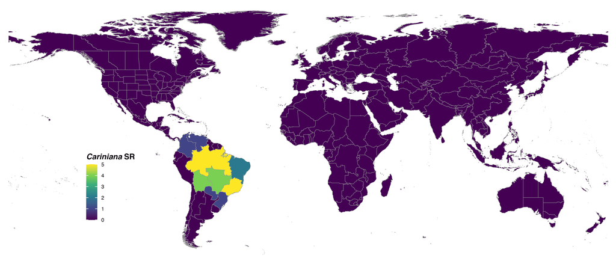

FIGURE 2. Global species richness of the genus *Cariniana* at botanical country level and colored with viridis scale.

```r
powoMap(inputdf = mapspdist,
        botctrs = TRUE,
        distcol = "native_to_botanical_countries",
        taxclas = "genus",
        verbose = FALSE,
        save = FALSE,
        vir_color = "viridis",
        bre_color = NULL,
        leg_title = "SR",
        dpi = 600,
        dir = "results_powoMap",
        filename = "global_richness_botcountry_map",
        format = "jpg")
```

# 4. Creating global-scale map of species richness for an entire family

To generate a family-level global distribution map of species richness, use `powoSpecies` function without any genus constraint so as to query a full species list of the desired family and the associated distribution data. Then, the resulting query object should be used as input data of the `powoMap` function.

```r
mapspdist <- powoSpecies(family = "Lecythidaceae",
                         genus = NULL,
                         hybridspp = FALSE,
                         country = NULL,
                         verbose = FALSE,
                         save = FALSE,
                         dir = "results_powoSpecies",
                         filename = "Lecythidaceae")
```

The example below uses the previously generated dataframe-formatted `mapspdist` object as input data to `powoMap` function, with the `distcol` argument set as “native_to_country”, the `taxclas` argument set as `"family"`, the `vir_color` argument set as “viridis”, and the `bre_color` argument set as “Spectral”, so as to automatically produce two **global distribution maps** of all Lecythidaceae’s species richness at **country level**, which are distinctly colored by `Viridis` and `RColorBrewer` color palettes.

Note that if you had set here the `taxclas` as `"genus"`, then the `powoMap` function would have produced individual distribution maps of species richness for every single genus within Lecythidaceae, all of them being stored in the desired directory at `dir` argument.

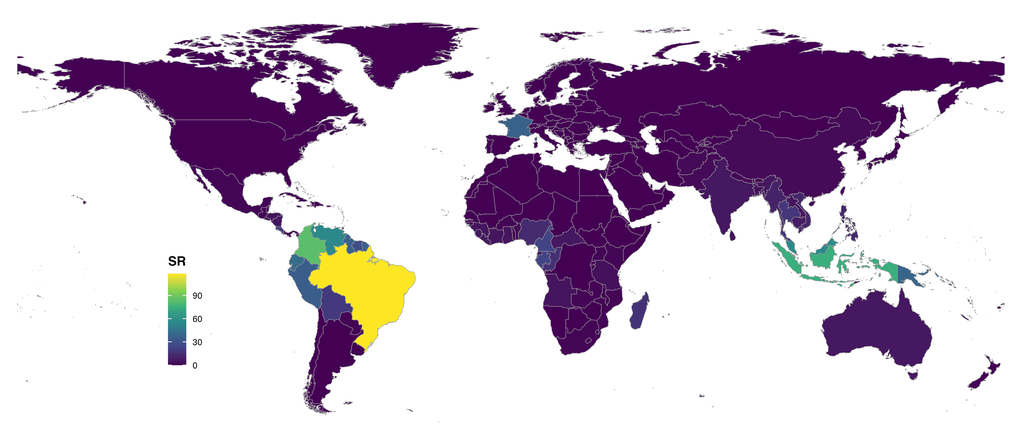

FIGURE 3. Global species richness of Lecythidaceae at country level and colored with viridis scale.

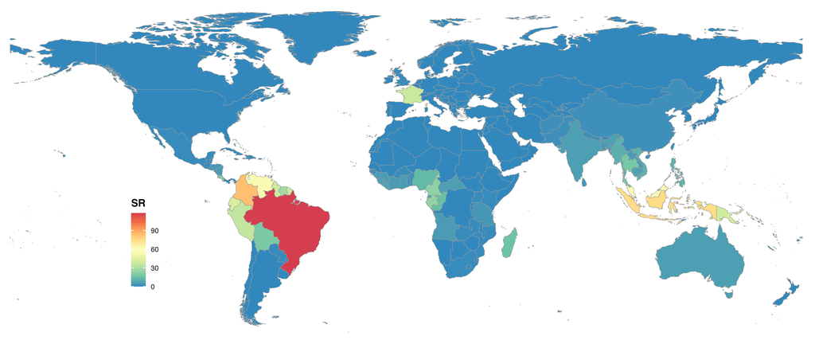

FIGURE 4. Global species richness of Lecythidaceae at country level and colored with Spectral scale.

```r
powoMap(inputdf = mapspdist,
        botctrs = FALSE,
        distcol = "native_to_country",
        taxclas = "family",
        verbose = FALSE,
        save = FALSE,
        vir_color = "viridis",
        bre_color = "Spectral",
        leg_title = "SR",
        dpi = 600,
        dir = "results_powoMap/",
        filename = "global_richness_botcountry_map",
        format = "jpg")
```

To create global maps of Lecythidaceae according to botanical countries, change the argument `distcol` to “native_to_botanical_countries”, the `vir_color` argument to “viridis”, and the `bre_color` argument to “Spectral”. This automatically produce two global distribution maps of Lecythidaceae’s species richness at botanical countries, which are distinctly colored by `Viridis` and `RColorBrewer` color palettes.

Note that if you had set here the `taxclas` as `"genus"`, then the `powoMap` function would have produced individual distribution maps of species richness for every single genus within Lecythidaceae, all of them being stored in the desired directory at `dir` argument.

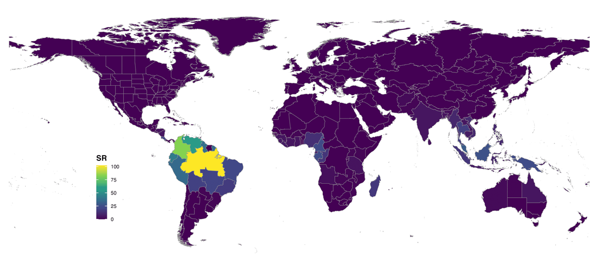

FIGURE 5. Global species richness of Lecythidaceae at botanical countries and colored with viridis scale.

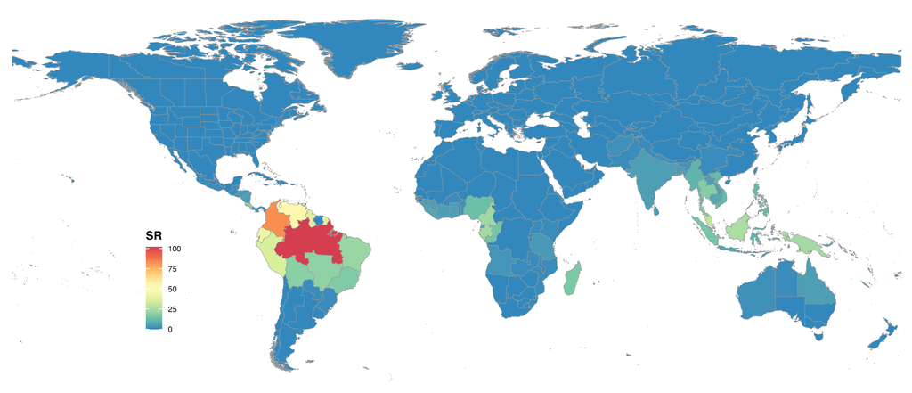

FIGURE 6. Global species richness of Lecythidaceae at botanical countries and colored with Spectral scale.

```r
powoMap(inputdf = mapspdist,
        botctrs = TRUE,
        distcol = "native_to_botanical_countries",
        taxclas = "family",
        verbose = FALSE,
        save = FALSE,
        vir_color = "viridis",
        bre_color = "Spectral",
        leg_title = "SR",
        dpi = 600,
        dir = "results_powoMap",
        filename = "global_richness_botcountry_map",
        format = "jpg")
```

# 5. Using an external spreadsheet as input data in powoMap

It is possible to use data from other databases in order to create global maps using our `powoMap` function. To perform this task, the spreadsheet must have at least a column with species names and one or two columns with associated distribution in the countries and/or botanical countries. The species names must be binomial, and the country names must be written in full and separated by a comma and a space right after to the `powoMap` function works properly. The data frame generated by our function `powoSpecies` can be used as a model to create this standard spreadsheet (see the examples above).

To use your external dataset as an imported spreadsheet, you must provide the name of the object in the argument `inputdf`. The `powoMap` function also will need information about the taxon level to generate the maps. To do so, the user must provide the name of the correspondent column in the argument `taxclas` (e.g., `"family"`, `"genus"`). To indicate the column with the distribution, change the `distcol` argument. If the distribution is according to political country names (e.g., Brazil, Peru), you just have to write the name of the column with this data. Otherwise, if you need global maps according to the TDWG botanical countries (level 3), you must indicate in which column this data (e.g., Brazil North, Peru) is stored and also change the argument `botctrs` from FALSE to TRUE.

# 6. Reference

POWO (2019). “Plants of the World Online. Facilitated by the Royal Botanic Gardens, Kew. Published on the Internet; https://powo.science.kew.org/ Retrieved April 2023.”